# Basic of the R lenguage

## Missing values

In R, missing values are represented by the symbol NA (not available). Impossible values (e.g., dividing by zero) are represented by the symbol NaN (not a number).

```r
# Data with missing values
y <- c(3,1,NA,4,6,NA)

# Return logical vectors
is.na(y)

# Replacing a missing value
y[is.na(y)==TRUE] <- 1

y[!is.na(y)]
```

[output not shown]

## Functions

One of the great strengths of R is the user’s ability to add functions. In fact, many of the functions in R are actually functions of functions. An example of a function is given below.

```r
my_function <- function(x) {
        fx <- log(x + (x^2)/2 + (x^3)/3 + (x^4)/4 + (x^5)/5)
        return(fx)
    }
my_function(1)
```

```
[1] 0.8256364
```

```r
my_function(2)
```

```
[1] 2.837127
```

## Loops

Loops are used in programming to repeat a specific block of code.

### For loops

A `for loop` is used to iterate over a list of values (a vectors). Example

```r
# For loop on list of characters
list_words <- c("Welcome", "to", "the", "Introduction","to","R")
for (i in list_words) {
    print(i)
}
```

```
[1] "Welcome"
[1] "to"
[1] "the"
[1] "Introduction"
[1] "to"
[1] "R"
```

```r
# For loop on list of numbers
for (i in 1:50) {
    r <- my_function(i)
    print(r)
}
```

```
[1] 0.8256364
[1] 2.837127
[1] 4.44676
[1] 5.710868
[1] 6.733898
[1] 7.588425
[1] 8.320566
[1] 8.960374
[1] 9.528252
[1] 10.0386
[1] 10.50193
[1] 10.92613
[1] 11.31726
[1] 11.6801
[1] 12.01844
```

[output cut: 35 more lines]

```r
my_function(1:50)
```

```
 [1]  0.8256364  2.8371272  4.4467604  5.7108684  6.7338978  7.5884249  8.3205658  8.9603736
 [9]  9.5282521 10.0386010 10.5019288 10.9261255 11.3172595 11.6800950 12.0184395 12.3353825
[17] 12.6334650 12.9148018 13.1811715 13.4340842 13.6748325 13.9045317 14.1241505 14.3345358
[25] 14.5364320 14.7304972 14.9173158 15.0974092 15.2712445 15.4392418 15.6017804 15.7592035
[33] 15.9118234 16.0599242 16.2037659 16.3435865 16.4796045 16.6120214 16.7410227 16.8667803
[41] 16.9894533 17.1091892 17.2261254 17.3403899 17.4521018 17.5613729 17.6683074 17.7730032
[49] 17.8755520 17.9760402
```

### While loops

`While loops` are used to loop until a specific condition is met. Example

```r
# start on value i=1
i=1
trace <- NULL
# redefine i such i equals i + function(i). Stop when i take on value 100 or more.
while (i < 100) {
  trace <- rbind(trace,c(i,i + my_function(i)))
    i = i + my_function(i)
}
trace
```

```
           [,1]       [,2]
 [1,]  1.000000   1.825636
 [2,]  1.825636   4.339578
 [3,]  4.339578  10.420555
 [4,] 10.420555  20.659235
 [5,] 20.659235  34.253323
 [6,] 34.253323  50.350078
 [7,] 50.350078  68.360826
 [8,] 68.360826  87.893866
 [9,] 87.893866 108.679416
```

## Plots

Here is just introduce the two most basic types of plots, namely histograms and scatterplots.

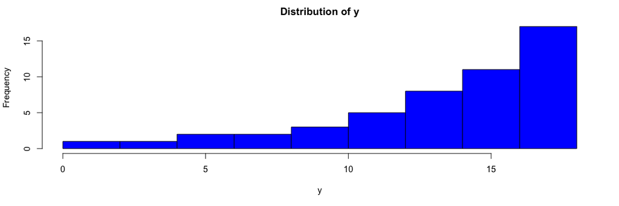

```r
x <- 1:50
y <- my_function(1:50)
# Histogram
hist(y, col="blue", main="Distribution of y")
```

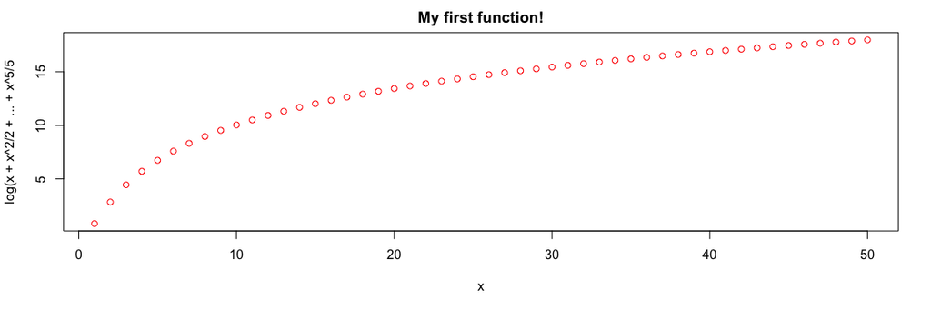

```r
# Scatterplot
plot(x,y, col="red", ylab="log(x + x^2/2 + ... + x^5/5", main="My first function!")
```